# Os tipos de filme de Meryl Streep

Problema 3 - Checkpoint 1

Hugo Gabriel

## Introdução

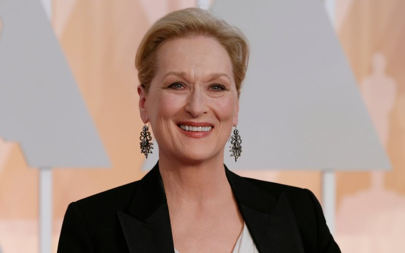

## Descrição dos dados de variáveis

Os dados usados nessa análise são do [Rotten Tomatoes](https://www.rottentomatoes.com/) que é um site americano especializado em resumos, informações e novidades sobre filmes, séries, curtas-metragens e videos musicais.<sup>[[2]](https://pt.wikipedia.org/wiki/Rotten_Tomatoes)</sup>

Os dados obtidos contam com as seguintes variáveis:

| Dado | Descrição |
| --- | --- |
| **RATING** | Representa a porcentagem de críticas profissionais que são positivas para um determinado filme |
| **TITLE** | Nome do Filme |
| **CREDIT** | Papel interpretado pela atriz |
| **BOX OFFICE** | Valor arrecadado pela bilhereria do filme (em milhões de dólares) |
| **YEAR** | Ano de lançamento do filme |

Para agrupar os filmes usaremos as variáveIs **Box Office** e **Rating** pois elas de mostraram mais úteis e significativas para classificar o trabalho da atriz.

Ao todo estão disponíveis no site 97 filmes nos quais a atriz interpretou, no entanto, não foi possível utilizar todos eles na análise pois nem todos tinham valores para as variáveis usadas neste relatório, então ao considerar apenas os filmes que possuiam valores de Box Office e de Rating ficamos com 24 observações para a nossa análise com o seguinte comportamento:

- **Rating**
  - Valor Máximo: 92%
  - Valor Mínimo: 27%
  - Média: 64.71%
  - Mediana: 67.5%
- **Box Office**
  - Valor Máximo: $143.8M
  - Valor Mínimo: $7.2M
  - Média: $49.8M
  - Mediana: $31.75M

O gráfico abaixo apresenta o comportamento as variáveis juntas.

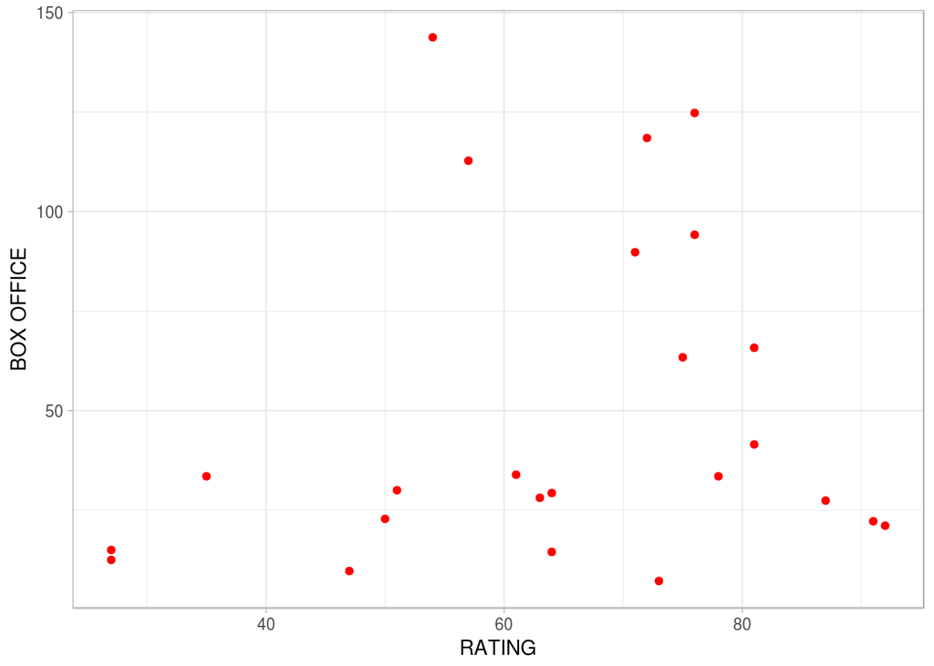

## Agrupamento

Para decidir sobre o número de grupos que teremos observaremos o dendograma a seguir, que é uma visualização que mostra como foi a execução do método de agrupamento usado, quanto mais longa uma linha mais dissimilaridade teve que ser incorporada para unir os filmes em um único grupo. Observe que ao final, temos um grupo único com todos os filmes.

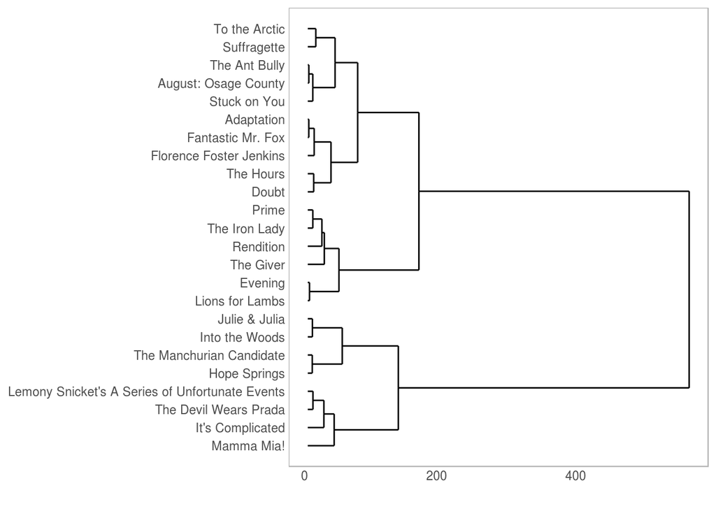

Parece ser uma boa escolha dividir os filmes em **5 grupos**, os gráfico abaixo podem nos dar mais segurança sobre esta decisão.

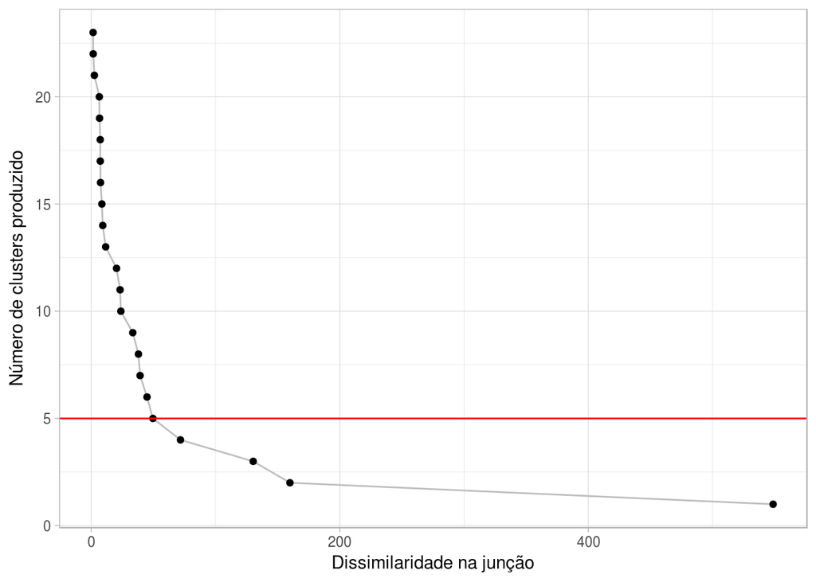

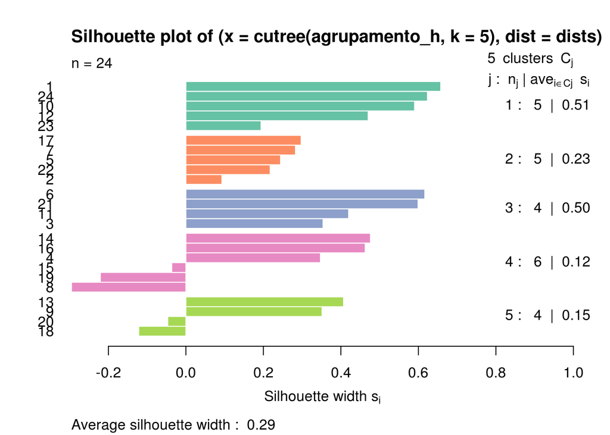

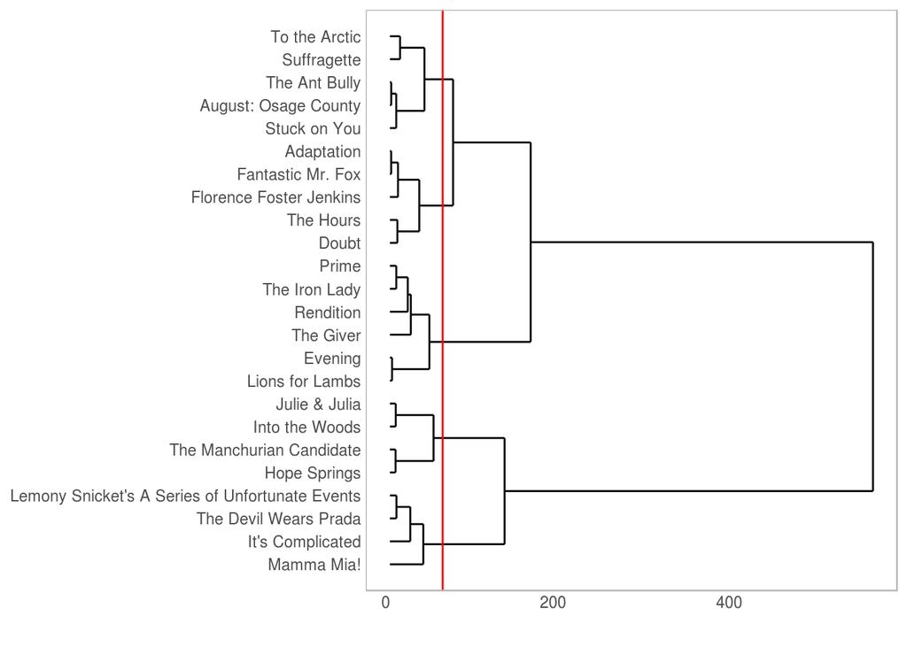

E com isso obtemos os seguintes grupos:

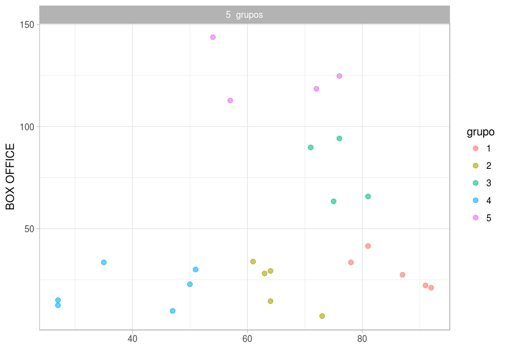